# WofostR

R implementation of Wofost crop simulation model

See [De Wit et al. (2019)](https://doi.org/10.1016/j.agsy.2018.06.018) for details.

Python version available at [ajdewit/pcse](https://github.com/ajwdewit/pcse.git) as part of the Python Crop Simulation Environment (PCSE/WOFOST).

### Installation

Install with:

```r
devtools::install_github('lucabutikofer/WofostR',
                         build_opts = c("--no-resave-data", "--no-manual"),
                         build_vignettes = T)
```

### Testing

```r
test(component = 'phenology', complete = TRUE)
test()
```

### Input files

Four types of input files are required to run the Wofost():

- CropObjects
- WeatherObjects
- SoilObjects
- ManagerObjects

These are S4 classes containing the variables required by function `Wofost()`. Crop objects can be generated by calling `dwn.crop()` or `load.crop()` to download crops from the web or to load them from a local repository respectively. `dwn.crop()` retrieves specific crop parameters from [ajwdewit/WOFOST_crop_parameters](https://github.com/ajwdewit/WOFOST_crop_parameters.git) by specifying the crop and variety names. A list of corp and varieties names can be printed with `cropVarList`. `load.crop()` works in a similar way as `dwn.crop()` but reads .yaml files saved in the local directory `crLocal`.

```r
cr <- dwn.crop(cropName = "sugarbeet",
                        variety = "Sugarbeet_601")
cr
```

```
#>
#>  WofostR Crop Object:
#>  >> Crop name: sugarbeet
#>  >> Variety name: Sugarbeet_601
#>  >> 92 crop parameters out of 92 are specified.
#>
```

```r
str(cr, list.len = 3)
```

```
#> Formal class 'CropObject' [package "WofostR"] with 92 slots
#>   ..@ CROPNAME       : chr "sugarbeet"
#>   ..@ VARNAME        : chr "Sugarbeet_601"
#>   ..@ CO2EFFTB       : num [1:5, 1:2] 40 360 720 1000 2000 0 1 1.11 1.11 1.11
#>   .. ..- attr(*, "dimnames")=List of 2
#>   .. .. ..$ : NULL
#>   .. .. ..$ : chr [1:2] "x" "y"
#>   .. [list output truncated]
```

Weather objects must contain minimum and maximum temperature, radiation and latitude at daily time-steps starting from the day the model expected to start. An example weather object can be seen with `randomWeather`. WeatherObjects can be printed with the `plot()` function.

```r
randomWeather
```

```
#>
#>  WofostR Weather Object:
#>
#>  >> From date: 2010-04-16
#>  >> To date: 2010-12-31
#>
#>    VARIABLES  LENGTH
#> 1  @DAY       260
#> 2  @E0        260
#> 3  @ELEV      260
#> 4  @ES0       260
#> 5  @ET0       260
#> 6  @IRRAD     260
#> 7  @LAT       260
#> 8  @LON       260
#> 9  @RAIN      260
#> 10 @SNOWDEPTH 260
#> 11 @TEMP      260
#> 12 @TMAX      260
#> 13 @TMIN      260
#> 14 @VAP       260
#> 15 @WIND      260
```

```r
str(randomWeather, list.len = 3)
```

```
#> Formal class 'WeatherObject' [package "WofostR"] with 15 slots
#>   ..@ DAY      : Date[1:260], format: "2010-04-16" ...
#>   ..@ E0       : num [1:260] 0.292 0.307 0.303 0.345 0.332 0.295 0.288 0.333 0.369 0.439 ...
#>   ..@ ELEV     : num [1:260] 440 440 440 440 440 440 440 440 440 440 ...
#>   .. [list output truncated]
```

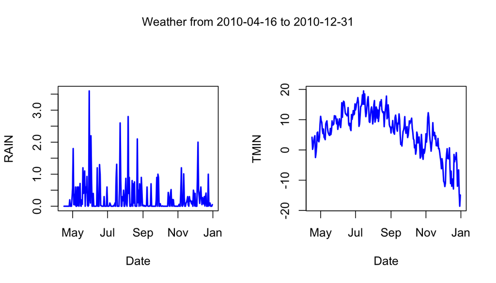

```r
plot(randomWeather, var = c('RAIN','TMIN'))
```

SoilObjects are used to compute water-limited production (`Wofost(... , waterLimited = T)`) and contain soil variables for a single location. An example weather object can be seen with `randomSoil`.

```r
randomSoil
```

```
#>
#>  WofostR Soil Object:
#>  >> 14 soil parameters out of 14 are specified.
#>
```

```r
str(randomSoil)
```

```
#> Formal class 'SoilObject' [package "WofostR"] with 14 slots
#>   ..@ SMFCF : num 0.318
#>   ..@ SM0   : num 0.415
#>   ..@ SMW   : num 0.151
#>   ..@ CRAIRC: num 0.06
#>   ..@ SOPE  : num 10
#>   ..@ KSUB  : num 10
#>   ..@ K0    : num 10
#>   ..@ RDMSOL: num 60
#>   ..@ IFUNRN: int 0
#>   ..@ SSMAX : num 0
#>   ..@ SSI   : num 0
#>   ..@ WAV   : num 10
#>   ..@ NOTINF: num 0
#>   ..@ SMLIM : num 0.318
```

ManagerObjects are used to run a sequence of crops simulation in succession for the same location (e.g. a crop rotation or the same crop over multiple years). An example ManagerObject can be seen with `exampleManager`.

```r
mo <- ManagerObject(
        cropSequence = c(
          'barley-Spring_barley_301',
          'millet-Millet_VanHeemst_1988',
          'maize-Grain_maize_201'),
        sequenceStart = '2010/04/16',
        sequenceFinish = '2012/01/01',
        cropStartType = c('sowing', 'sowing', 'sowing'),
        cropStartDate = c(NA, '2011/04/16', NA),
        cropFinish = c('maturity','2011/05/16','maturity'),
        spacing = c(0, NA, 10 )
      )
mo
```

```
#>
#>  WofostR Manager Object:
#>  >> Starting sequence: 2010/04/16
#>  >> Finishing sequence: 2012/01/01
#>  >> Crop rotation:
#>
#>      Crops                        Start_types Start_dates Finish
#> [1,] barley-Spring_barley_301     sowing      <NA>        maturity
#> [2,] millet-Millet_VanHeemst_1988 sowing      2011/04/16  2011/05/16
#> [3,] maize-Grain_maize_201        sowing      <NA>        maturity
#>      Spacing
#> [1,] 0
#> [2,] <NA>
#> [3,] 10
```

### Running Wofost

Wofost crop simulation model is run by functions `Wofost()`. Potential Production and Free Draining water-limited production are called by setting variable `waterLimited` to `FALSE` or `TRUE` respectively.

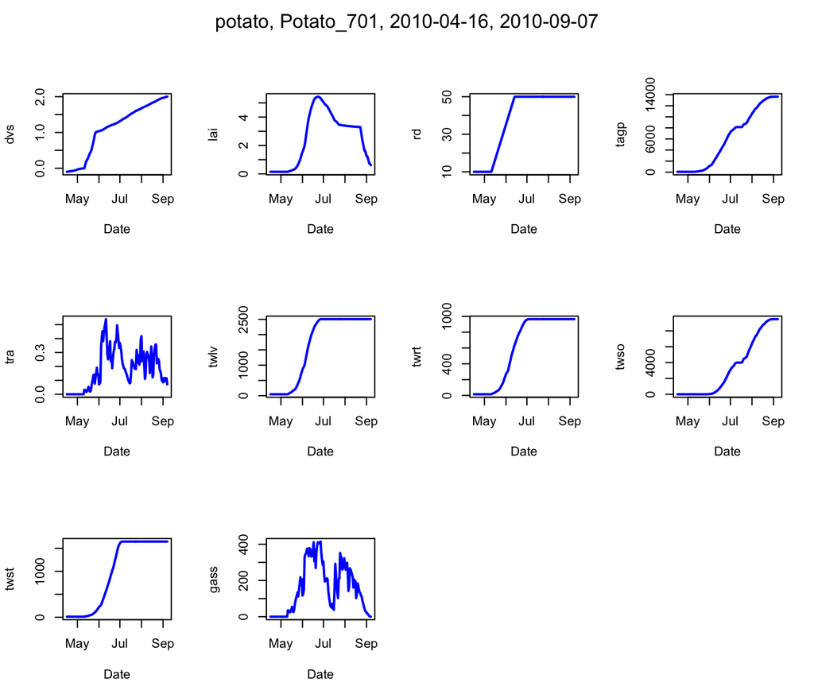

```r
# Run Potential Production
outPP <- Wofost(crop = dwn.crop(), w = randomWeather)
# Run Water-Limited Production
outFD <- Wofost(crop = dwn.crop(), w = randomWeather, soil = randomSoil,
                waterLimited = TRUE)
plot(outFD)
```

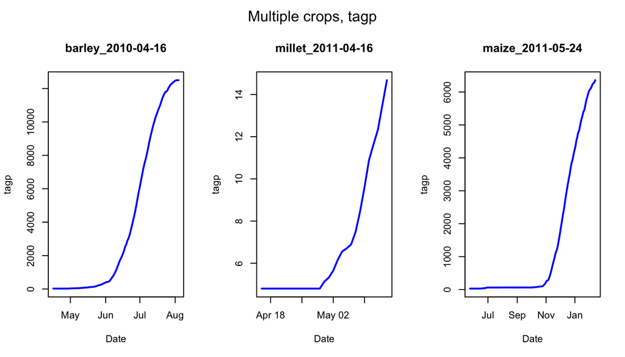

```r
# Run crop rotation with ManagerObject
outMN <- Wofost(w = randomWeatherLong, manager = exampleManager)
plot(outMN, var = 'tagp')
```

### Available Crops and Varieties

| crop | variety |
| --- | --- |
| barley | Spring_barley_301 |
| cassava | Cassava_VanHeemst_1988 |
| chickpea | Chickpea_VanHeemst_1988 |
| cotton | Cotton_VanHeemst_1988 |
| cowpea | Cowpea_VanHeemst_1988 |
| fababean | Faba_bean_801 |
| groundnut | Groundnut_VanHeemst_1988 |
| maize | Maize_VanHeemst_1988 |
| maize | Grain_maize_201 |
| maize | Grain_maize_202 |
| maize | Grain_maize_203 |
| maize | Grain_maize_204 |
| maize | Grain_maize_205 |
| millet | Millet_VanHeemst_1988 |
| mungbean | Mungbean_VanHeemst_1988 |
| pigeonpea | Pigeonpea_VanHeemst_1988 |
| potato | Potato_701 |
| potato | Potato_702 |
| potato | Potato_703 |
| potato | Potato_704 |
| rapeseed | Oilseed_rape_1001 |
| rapeseed | Oilseed_rape_1002 |
| rapeseed | Oilseed_rape_1003 |
| rapeseed | Oilseed_rape_1004 |
| rice | Rice_501 |
| rice | Rice_HYV_IR8 |
| rice | Rice_IR64616H_DS |
| rice | Rice_IR64616H_WS |
| rice | Rice_IR64 |
| rice | Rice_IR72 |
| rice | Rice_IR72_DS |
| rice | Rice_IR72_WS |
| rice | Rice_IR8A |
| sorghum | Sorghum_VanHeemst_1988 |
| soybean | Soybean_901 |
| soybean | Soybean_902 |
| soybean | Soybean_903 |
| soybean | Soybean_904 |
| soybean | Soybean_905 |
| soybean | Soybean_906 |
| soybean | Soybean_VanHeemst_1988 |
| sugarbeet | Sugarbeet_601 |
| sugarbeet | Sugarbeet_602 |
| sugarbeet | Sugarbeet_603 |
| sugarbeet | Sugarbeet_604 |
| sugarcane | Sugarcane_VanHeemst_1988 |
| sunflower | Sunflower_1101 |
| sweetpotato | Sweetpotato_VanHeemst_1988 |
| tobacco | Tobacco_VanHeemst_1988 |
| wheat | Winter_wheat_101 |
| wheat | Winter_wheat_102 |
| wheat | Winter_wheat_103 |
| wheat | Winter_wheat_104 |
| wheat | Winter_wheat_105 |
| wheat | Winter_wheat_106 |
| wheat | Winter_wheat_107 |